Faculty of Economic Sciences

Advanced programming in R - Academic year 2020/2021

10. Web application with Shiny R part 2

# Application optimization and reactive programming

Piotr Ćwiakowski

06 maj, 2021

# Performance optimization of shiny apps

Shiny application, like any other tool, has limits and performance issues. When our software is used by few users in the same time or computations take less than 1 second (in businness cases milisecond), that does not really matter, how we design it.

Although very often we aim ambitiously, we intend to create application interesting for many people (which entails many simultanous users and/or app with dosens of visualisations of abundant datasets. Thus, code of app need to be efficient. How build application to make them achieve those goals?

Obviously, we need to use efficient formats packages and functions, like `data.table` for large datasets or binary format (`.Rdata` and `.rds`) for importing data or `rcpp` for really fast computing. But not only. The very important matter is design of `server.R` file. Basically are of this file can be divided into three zones, which have different status whithin application.

**Zone 1.**

To the first zone belongs all the code placed **outside** anonymous shiny server function (see picture below, referring zone is coloured in blue). Code in this section will be executed exactly once, when app will be initiated on the server. That’s why in this zone we upload datasets, libraries and any other necessary resources (for example scripts with functions).

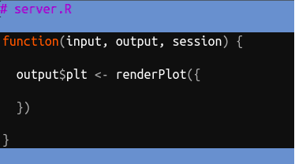

**Zone 2.**

Second is part of the code, which is inside anonymous function but outside `render*` functions. This zone is run once for each session (or we may say for each active user who accessed/opened application in browser). When you open your app in RStudio, thus **locally** you cannot run different session for one launch of app, thus you cannot distinct zone 1, from zone 2. But in reality you may and you should. Consider following example. Imagine that you deployed an application in company, which displays some analitycal dashboards for management board from previous 7 days. Each day you update dataset with newest records and relaunch application every morning. Members of the board access dashboards many times a day every day. Thus loading datasets should be placed in zone 1, because we do not want them to import in every session (when manager open app in browser) but only once a day, after update you made when you re-run application. In zone 2., within anonymous function, but outside render functions should be placed elements specific to the user like number of the session.

If you still do not understand clearly the difference between zone 1. and 2. don’t worry - this will not affect further reading and your project - because it is more related with deployment in business environment rather than use for academic/teaching purposes. The critical difference is between zone 1./2. and 3.

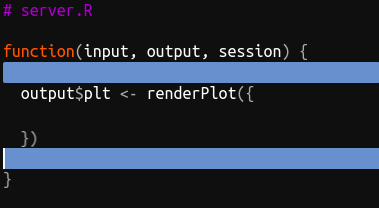

**Zone 3.**

Last but not least zone is area inside `render*` functions. This lines of code depend on the choices made by the users in UI, so they are recomputed each time users behaviour results in changing of the values of `input` list used in given `render function`. Because this functions **reacts** to the behaviour of users, we may describe thise functions as reactive functions. Only in reactive functions values from `input` list can be used. On the other hand, `render*` functions are not the only functions which allows reactivity and during this lesson we learn about others.

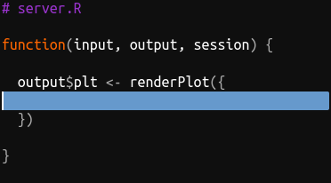

To sum up:

1. Outside `server` function code common for all users should be placed (for example data import).
2. Inside server function and `outside` reactive functions should be placed session-specific code for the user which does not depend on his further behaviour - for example id/number of the session or data preprocessing for user with certain privilages.
3. Inside reactive function should be placed other code dependent on values from `input` list (i. e. user behaviour).

# Reactive values

Let’s consider following example, which utilizes data scraped from gumtree.pl, very popular website with flat rental advertisements. Data consists following columns:

| Variable name | Description |
| --- | --- |
| date | Date of publishing the announcement |
| disctrict | District of the flat |
| description | Description of announcement (in Polish) |
| price | amount of the rent |
| who_published | who published the offer (Agency/Owner) |
| rooms | amount of rooms in the flat |
| type_of_real_estate | House/Apartment/Other |
| footage | footage in square meters |
| parking_space | Type of parking space (No/Garage/Indoor/Street) |
| bathrooms | Number of bedrooms |
| availability | Availability date |
| smokers | Are smokers allowed? (Yes/No) |
| animals | Are animals allowed? (Yes/No) |
| words_in_desc | Number of words in description |

Exemplary application will be very simple, with one histogram and one wdget for filtering footage range. If you want to check how it works by yourself, just creat `ui.R` and `server.R` in destination folder of your choice, copy there code from below tabs and create a folder `data` with dataset `gumtree_en.rds`.

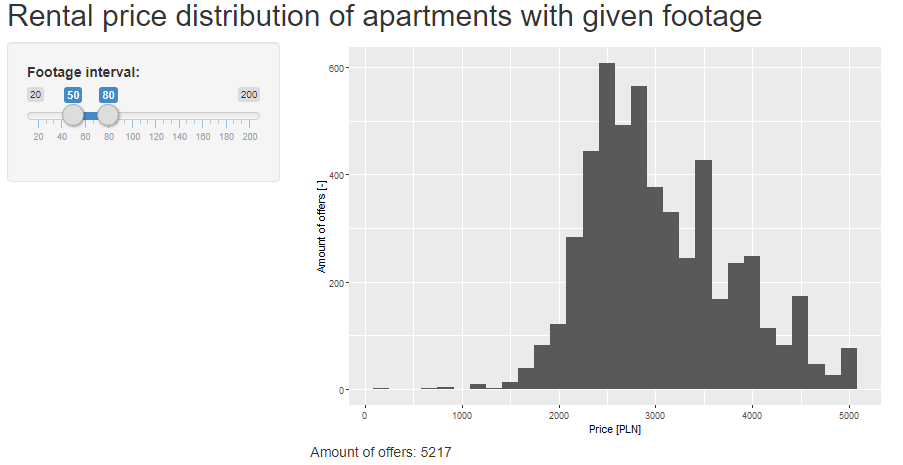

## Code of exemplary app

### ui.R

```r
ui <- fluidPage(
  titlePanel("Rental price distribution of apartments with given footage"),
  sidebarLayout(
    sidebarPanel(
      sliderInput("sqrt_m2", HTML("Footage interval:"),
                  min = 20, max = 200, value = c(50, 80), step = 10)
    ),
    mainPanel(
      plotOutput("plt"),
      textOutput("obs"),
      textOutput("avg")
    )
  )
)
```

### server.R

```r
library(tidyverse)

data <- readRDS("data/gumtree_en.rds") %>%
  filter(price <= 5000)

server <- function(input, output, session) {
  output$plt <- renderPlot({
    data %>%
      filter(
        between(footage, input$sqrt_m2[1], input$sqrt_m2[2])) %>%
      ggplot(aes(price)) +
      geom_histogram() +
      xlab(expression("Price [PLN]")) +
      ylab("Amount of offers [-]")
  })
  output$obs <- renderText({
    data %>%
      filter(
        between(footage, input$sqrt_m2[1], input$sqrt_m2[2])) %>%
      summarise(obs = n()) %>%
      pull(obs) %>%
      paste("Amount of offers:", .)
  })

  output$avg <- renderText({
    data %>%
      filter(
        between(footage, input$sqrt_m2[1], input$sqrt_m2[2])) %>%
      summarise(avg = round(mean(price, na.rm  = TRUE), 2)) %>%
      pull(avg) %>%
      paste("Amount of offers:", .)
  })
}
```

Is code of the application optimal? According to information presented in first chapter yes. But let’s considet it from another angle. Notice, that if user changes the range of footage, dataset is filtered three times - one in each render function. This is clearly ineffective and quickly slow down app when dataset will be really large. What should we do? The perfect solution would be placing filtering once, before renedering function. But it means, that we will place the code in zone 2, which is evaluated once per session and does not allowed for reactive values (like that on `input` list). That’s why this solution will result in error. But let’s test it for you own - copy code to your test files and run the app.

## Wrong solution

### ui.R

```r
ui <- fluidPage(
  titlePanel("Rental price distribution of apartments with given footage"),
  sidebarLayout(
    sidebarPanel(
      sliderInput("sqrt_m2", HTML("Footage interval:"),
                  min = 20, max = 200, value = c(50, 80), step = 10)
    ),
    mainPanel(
      plotOutput("plt"),
      textOutput("obs"),
      textOutput("avg")
    )
  )
)
```

### server.R

```r
library(tidyverse)

data <- readRDS("data/gumtree_en.rds") %>%
  filter(price <= 5000)

server <- function(input, output, session) {
  # New common filtering
  data_filtered <-  data %>%
    filter(
      between(footage, input$sqrt_m2[1], input$sqrt_m2[2]))

  # Rest of the code (unchanged)
  output$plt <- renderPlot({
    data_filtesred %>%
      ggplot(aes(price)) +
      geom_histogram() +
      xlab(expression("Price [PLN]")) +
      ylab("Amount of offers [-]")
  })
  output$obs <- renderText({
    data_filtered %>%
      summarise(obs = n()) %>%
      pull(obs) %>%
      paste("Amount of offers:", .)
  })

  output$avg <- renderText({
    data_filtered %>%
      summarise(avg = round(mean(price, na.rm  = TRUE), 2)) %>%
      pull(avg) %>%
      paste("Average price:", .)
  })
}
```

Running apllication results in following error:

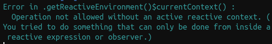

From the description of the error we can learn, that we placed some reactive value in forbidden area. This is because `input` values are reactive (reactive because they change/reacts to the beahviour of an user) and we placed them in zone 2. So, we have an urgent need to know the function, which allows for reactive expressions outside render functions. Here it is - `shiny::reactive()`.

## reactive() function

**Name:**

`shiny::reactive(x)`

**Arguments:**

`x` - expression which returns value

**Description:**

Wraps a normal expression to create a reactive expression. Conceptually, a reactive expression is a expression whose result will change over time. Unlike `render*()` it does not sends an object to `output` list - instead creates a reactive variable (so it will change when certain input value will change). Interior of function `reactive` belongs to zone 3. **IMPORTANT:** to object created by `reactive()` function one should refer by its name and brackets: `()`.

**Variable creation:**

- Classic variable: `name_of_var <- <expr which computes variable>`
- Reactive variable: `name_of_var <- reactive({<expr which computes variable>})`

**Variable call:**

- Classic variable: `name_of_var`
- Reactive variable: `name_of_var()`

## Correct solution

### ui.R

```r
ui <- fluidPage(
  titlePanel("Rental price distribution of apartments with given footage"),
  sidebarLayout(
    sidebarPanel(
      sliderInput("sqrt_m2", HTML("Footage interval:"),
                  min = 20, max = 200, value = c(50, 80), step = 10)
    ),
    mainPanel(
      plotOutput("plt"),
      textOutput("obs"),
      textOutput("avg")
    )
  )
)
```

### server.R

```r
library(tidyverse)

data <- readRDS("data/gumtree_en.rds") %>%
  filter(price <= 5000)

server <- function(input, output, session) {
  data_filtered <- reactive({data %>%
      filter(
        between(footage, input$sqrt_m2[1], input$sqrt_m2[2]))
  })
  output$plt <- renderPlot({
    data_filtered() %>%
      ggplot(aes(price)) +
      geom_histogram() +
      xlab(expression("Cena [PLN]")) +
      ylab("Amount of offers [-]")
  })
  output$obs <- renderText({
    data_filtered() %>%
      summarise(obs = n()) %>%
      pull(obs) %>%
      paste("Amount of offers:", .)
  })

  output$avg <- renderText({
    data_filtered() %>%
      summarise(avg = round(mean(price, na.rm  = TRUE), 2)) %>%
      pull(avg) %>%
      paste("Average price:", .)
  })
}
```

## Exercise - reactive training

In folowing app change the code and replace all the variables (`data`, `dates_tbl`, `factors_tbl`, `numeric_tbl`) to reactive variables.

### ui.R

```r
ui <- fluidPage(
  titlePanel("fileInput"),
  sidebarLayout(
    sidebarPanel(
      fileInput(
        inputId = "info",
        label = "Choose file from disk:",
        accept = c(".csv", ".txt"),
        buttonLabel = icon("folder"),
        placeholder = "Allowed *.csv/*.txt"
      ),
      checkboxGroupInput(
        inputId = "types",
        label = "Choose type of columns:",
        selected = "numerics",
        choiceNames = c("Dates", "Nominal", "Continuous"),
        choiceValues = c("dates", "factors", "numerics")
      )
    ),
    mainPanel(
      textOutput("txt"),
      tags$br(),
      verbatimTextOutput("sum")
    )
  )
)
```

### server.R

```r
library(lubridate)
library(tidyverse)

options(shiny.maxRequestSize = 20 * 1024 ^ 2)

Sys.setlocale(category = "LC_ALL", locale = "Polish")

server <- function(input, output, session) {
  output$txt <- renderText({
    if (is.null(input$info)) {
      return("Does not read any file yet.")
    }

    str_c("File", input$info$name, "of size",
          input$info$size, "KB i and with extention", input$info$type, "has been imported.",
          sep = " ") %>%
      str_c(".\n")
  })

  output$sum <- renderPrint({
    if (is.null(input$info)) {
      return("Missing data.")
    }

    data <- input$info$datapath %>%
      read_csv() %>%
      select(-one_of('description')) %>%
      mutate_if(is.character, as_factor)

    dates_tbl <- if ("dates" %in% input$types) {
      data %>%
        select_if(is.Date)
    } else {
      data %>%
        select()
    }

    factors_tbl <- if ("factors" %in% input$types) {
      data %>%
        select_if(is.factor)
    } else {
      data %>%
        select()
    }

    numerics_tbl <- if ("numerics" %in% input$types) {
      data %>%
        select_if(is.numeric)
    } else {
      data %>%
        select()
    }

    bind_cols(dates_tbl, factors_tbl, numerics_tbl) %>%
      summary()
  })
}
```

## Exercise - computing optimisation with reactive variables

In below app in render function following activites are performed:

- filtering,
- generating base bar graph,
- generating circle graph based from bar graph.

Optimise app by:

- moving filtering and base graph to zone 1.,
- creating reactive value for pie chart (yet without title),
- placing definition of the title as the final step within render function.

Can you describe, how this steps optimise computation and why creation of the title had to be separated from the reactive value?

### ui.R

```r
ui <- fluidPage(
  titlePanel("Choose type of chart with radio buttons widget"),
  sidebarLayout(
    sidebarPanel(
      radioButtons("type", "Type of chart:", choices = c("Bar", "Pie")),
      textInput("title", "Title of chart:")
    ),
    mainPanel(
      plotOutput("plt")
    )
  )
)
```

### server.R

```r
library(tidyverse)

data <- readRDS("data/gumtree_en.rds")

server <- function(input, output, session) {
  output$plt <- renderPlot({
    Sys.sleep(2)
    plt <- data %>%
      count(rooms) %>%
      mutate(per = round(n / sum(n) * 100)) %>%
      arrange(desc(rooms)) %>%
      ggplot(aes("", per, fill = rooms)) +
      geom_bar(stat = "identity") +
      scale_fill_discrete(name = "Number of rooms [-]") +
      xlab("") +
      ylab("Share of offers [%]") +
      ggtitle(input$title) +
      theme(plot.title = element_text(size = 30, hjust = 0.5))

    if (input$type == "Pie") {
      plt <- plt +
        coord_polar("y") +
        geom_text(aes(x = 1, y = cumsum(per) - per / 2,
                      label = str_c(per, "%")))
    }

    plt
  })
}
```

# Ignoring changes in reactive values

## Case study: curse of textInput widget

Up to know we have learnt how to capture reactive values into variables in our app. Now, we will learn, how to ignore it. To understand why, let’s discuss again example from last exercise with slight modification. To ensure that app will slow down below acceptable tolerance we added additionally code to delay reaction of R to changes in title with `textInput` widget. Copy the code to appropiate R scripts, try to enter any title of the chart and study the user experience. Probably you noticed it before with normal code. It is annoying, that chart does not react immedietely, right?

### ui.R

```r
ui <- fluidPage(
  titlePanel("Choose type of chart with radio buttons widget"),
  sidebarLayout(
    sidebarPanel(
      radioButtons("type", "Type of chart:", choices = c("Bar", "Pie")),
      textInput("title", "Title of chart:")
    ),
    mainPanel(
      plotOutput("plt")
    )
  )
)
```

### server.R

```r
library(tidyverse)

data <- readRDS("data/gumtree_en.rds") %>%
  count(rooms) %>%
  mutate(per = round(n / sum(n) * 100)) %>%
  arrange(desc(rooms))

base_plot <- data %>%
  ggplot(aes("", per, fill = rooms)) +
  geom_bar(stat = "identity") +
  scale_fill_discrete(name = "Number of rooms [-]") +
  xlab("") +
  ylab("Share of offers [%]") +
  theme(plot.title = element_text(size = 30, hjust = 0.5))

server <- function(input, output, session) {

  final_plot_wo_title <- reactive({
    plt <- base_plot
    if (input$type == "Pie") {
      plt <- plt +
        coord_polar("y") +
        geom_text(aes(x = 1, y = cumsum(per) - per / 2,
                      label = str_c(per, "%")))
    }
    plt
  })
  # here we slow down app on purpose:
  plot_title <- reactive({
    Sys.sleep(2)
    input$title
  })

  output$plt <- renderPlot({
    final_plot_wo_title() +
      ggtitle(plot_title())
  })
}
```

Let’s discuss the drawbacks of the code from above:

1. Each generation of the title lasts too long.
2. Title is updated even though we haven’t finished it.

This problem is called in shiny community as *text input curse*. In another words, the server property to react (in fact recompute all the calculations) on any change of input list is not a commonly disired idea. We would like to **isolate** some widgets from the constant reactivity. One way to deal with this problem is to use `submitButton` widget. Unfortunately this widget will freeze **all input widgets until we click on submitButton**, which is not a preferable solution, espescially from UX perspective. Somehow, we would like freeze some widgets until a curtain button is clicked (`actionButton`). Hence, we need a funtion to separate some `input` list values. We can do it with function **isolate**.

## isolate function

**Function name:**

`shiny::isolate(expr)`

**Arguments:**

`expr` - expression in R which returns a value.

**Description:**

Result of the code `isolate(expr)` is the same as `expr`. The difference is only that functon `isolate` “hides” changes of the reactive parameters used in `expr` thus its not visible for reactive functions (such as `render*`, `reactive`). That’s way expression within `isolate` does not cause any reactivity.

## Isolating in practice

Below solution adressing problem of *text input curse* is presented. Basically, it consists four steps:

1. Adding `actionButton`.
2. Creating new reactive variable which captures isolating text.
3. Adding reactive variable assigned to `actionButton` inside reactive expression.
4. Use this new variable in title modification.

Now only after clicking the button changing of title is performed.

### ui.R

```r
ui <- fluidPage(
  titlePanel("Choose a type of chart with radio buttons"),
  sidebarLayout(
    sidebarPanel(
      radioButtons("type", "Type of chart:", choices = c("Bar", "Pie")),
      textInput("title", "Tile of a chart:"),
      actionButton("accept_title", "Change title")
    ),
    mainPanel(
      plotOutput("plt")
    )
  )
)
```

### server.R

```r
library(tidyverse)

data <- readRDS("data/gumtree_en.rds") %>%
  count(rooms) %>%
  mutate(per = round(n / sum(n) * 100)) %>%
  arrange(desc(rooms))

base_plot <- data %>%
  ggplot(aes("", per, fill = rooms)) +
  geom_bar(stat = "identity") +
  scale_fill_discrete(name = "Number of rooms [-]") +
  xlab("") +
  ylab("Share of offers [%]") +
  theme(plot.title = element_text(size = 30, hjust = 0.5))

server <- function(input, output, session) {

  final_plot_wo_title <- reactive({
    plt <- base_plot
    if (input$type == "Pie") {
      plt <- plt +
        coord_polar("y") +
        geom_text(aes(x = 1, y = cumsum(per) - per / 2,
                      label = str_c(per, "%")))
    }
    plt
  })

  # new variable with reactive expression, placement of actionbutton value and isolate fun
  plot_title <- reactive({
    Sys.sleep(2)
    input$accept_title
    isolate(input$title)
  })


  output$plt <- renderPlot({
    final_plot_wo_title() +
      ggtitle(plot_title())
  })
}
```

## Exercise - slider curse

The curse is not tied only with one widget - unfortunetely it concerns also others, such as `sliderInput` or `numericInput`. Defeat course in below app, isolating appropiate expressions.

### ui.R

```r
ui <- fluidPage(
  titlePanel("Rental price vs footage in Warsaw metropolitan area"),
  sidebarLayout(
    sidebarPanel(
      sliderInput("price_max", "Maximum price [PLN]:",
                  min = 0, max = 5 * 10 ^ 5, value = 5 * 10 ^ 5,
                  step = 2 * 10 ^ 3),
      sliderInput("footage_max", HTML("Maximum footage [m<sup>2</sup>]:"),
                        min = 0, max = 6 * 10 ^ 3, value = 6 * 10 ^ 3, step = 250)
    ),
    mainPanel(
      plotOutput("plt")
    )
  )
)
```

### server.R

```r
library(tidyverse)

data <- readRDS("data/gumtree_en.rds") %>%
  filter(type_of_real_estate == "Apartment")


server <- function(input, output, session) {
  output$plt <- renderPlot({
    data %>%
      filter(footage <= input$footage_max) %>%
      filter(price <= input$price_max) %>%
      ggplot(aes(footage, price)) +
      geom_point() +
      xlab(expression("Footage ["*m^2*"]")) +
      ylab("Price [PLN]")
  })
  output$session_id <- renderText({
    paste("Session id: ", id_session)
  })
}
```

# Ignoring block of reactive code

## Ignoring block of codes

It turns out that inn busines practice people very often wanted to isolate some block of code with action button. Consider following example:

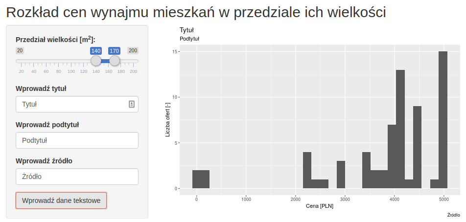

### ui.R

```r
ui <- fluidPage(
  titlePanel("Distribution of rental price in given footage range"),
  sidebarLayout(
    sidebarPanel(
      sliderInput("footage_m2", HTML("Footage interval [m<sup>2</sup>]:"),
                  min = 20, max = 200, value = c(50, 80), step = 10),
      textInput("plot_title", "Enter title"),
      textInput("plot_subtitle", "Enter subtittle"),
      textInput("plot_caption", "Enter footnote"),
      actionButton("accept_text", "Enter text data")
    ),
    mainPanel(
      plotOutput("plt")
    )
  )
)
```

### server.R

```r
library(tidyverse)

data <- readRDS("data/gumtree_en.rds") %>%
  filter(price <= 5000)

server <- function(input, output, session) {
  data_filtered <- reactive({
    data %>%
      filter(
        between(footage, input$footage_m2[1], input$footage_m2[2]))
  })

  plot_wo_text <- reactive({
    data_filtered() %>%
      ggplot(aes(price)) +
      geom_histogram() +
      xlab(expression("Price [PLN]")) +
      ylab("Number of offers [-]")
  })

  plot_with_text <- reactive({
    input$accept_text
    plot_wo_text() +
      labs(
        title = isolate(input$plot_title),
        subtitle = isolate(input$plot_subtitle),
        caption = isolate(input$plot_caption)
      )
  })

  output$plt <- renderPlot({
    plot_with_text()
  })
}
```

Let’s focus on this part of the code:

```r
  plot_with_text <- reactive({
    input$accept_text
    plot_wo_text() +
      labs(
        title = isolate(input$plot_title),
        subtitle = isolate(input$plot_subtitle),
        caption = isolate(input$plot_caption)
      )
  })
```

Of course the part which concern us the most is following:

```r
  labs(
    title = isolate(input$plot_title),
    subtitle = isolate(input$plot_subtitle),
    caption = isolate(input$plot_caption)
  )
```

Of course we can write also:

```r
plot_with_text <- reactive({
  input$accept_text
  plot_wo_text() +
    isolate({
      labs(
        title =input$plot_title,
        subtitle =input$plot_subtitle,
        caption =input$plot_caption
      )
    })
})
```

However because of following reasons:

- such a structure is very common in shiny apps,
- in extensive script `reactive()` functions with isolated expressions are hard to distinct from others (thus intention of the author of the code is not easy to catch),

shiny programmers come up with `eventReactive()` function.

## eventReactive function

**Function name:**

`shiny::eventReactive(eventExpr, valueExpr)`

**Arguments:**

`eventExpr` - expression which cause reactivity in `valueExpr`

`valueExpr` - isolated expression

**Descriptio:**

All in all, both code works exactly the same in shiny app:

```r
wartosc <- eventReactive(eventExpr, valueExpr)
```

```r
wartosc <- reactive({
  eventExpr
  isolate({
    valueExpr
  })
})
```

## eventReactive application

Last example can be modified as follows:

### ui.R

```r
ui <- fluidPage(
  titlePanel("Distribution of rental price in given footage range"),
  sidebarLayout(
    sidebarPanel(
      sliderInput("footage_m2", HTML("Footage interval [m<sup>2</sup>]:"),
                  min = 20, max = 200, value = c(50, 80), step = 10),
      textInput("plot_title", "Enter title"),
      textInput("plot_subtitle", "Enter subtittle"),
      textInput("plot_caption", "Enter footnote"),
      actionButton("accept_text", "Enter text data")
    ),
    mainPanel(
      plotOutput("plt")
    )
  )
)
```

### server.R

```r
library(tidyverse)

data <- readRDS("data/gumtree_en.rds") %>%
  filter(price <= 5000)

server <- function(input, output, session) {
  data_filtered <- reactive({
    data %>%
      filter(
        between(footage, input$footage_m2[1], input$footage_m2[2]))
  })

  plot_wo_text <- reactive({
    data_filtered() %>%
      ggplot(aes(price)) +
      geom_histogram() +
      xlab(expression("Price [PLN]")) +
      ylab("Number of offers [-]")
  })

  plot_with_text <- eventReactive({
    input$accept_text
    plot_wo_text()
  }, {
    plot_wo_text() +
      labs(
        title = input$plot_title,
        subtitle = input$plot_subtitle,
        caption = input$plot_caption
      )
  })

  output$plt <- renderPlot({
    plot_with_text()
  })
}
```

## Exercise

This time just a question: why in the first argument of `eventReactive` function we added `plot_wo_text()`?

# Reactivity without output

Until know, all the reactive functions returns something to the server environment (`render*`, `reactive`, `eventReactive`). However not always this is case. Sometimes, we would like some code to work without any output for the server. For example we would like to update log file which registers activity of the users. Such a step is not possible with known reactive function. We need a new function, which only observers reactive values, execute some procedures and do not return anything. We need `shiny::observe`. x

## Function observe

**Function name:**

`observe(x)`

**Arguments:**

`x` - expression executed reactively

**Description:**

Function observes executes code contained in argument `x`, in reaction to change of reaction values included in the expression. All values returned to `x` are ignored.

## Case study: exporting data to the external csv file

Below we present the code which store offers choosed by use to external csv file. Application use the package `DT` which is consists interactive table called returns by function `renderDataTable`. It allows to introduce interactivity on the output side. by default, when you clik on the output table, underlying row is selected and stored in `input` list object as `input$tab_rows_selected` (name of the field on input list and behaviour is default *par excellence*). In this field numbers of rows are stored and ready to further use, which we did in observe function. Isn’t it excellent?

### ui.R

```r
ui <- fluidPage(
  titlePanel("Offer selecting"),
  fluidRow(
    column(
      DT::dataTableOutput("tab"),
      width = 12)
  )
)
```

### server.R

```r
library(DT)
library(tidyverse)

Sys.setlocale(category = "LC_ALL", locale = "Polish")

data <- readRDS("data/gumtree_en.rds") %>%
  filter(between(price, 0, 10^4), between(footage, 0, 10^2))

opts <- list(
  language = list(url = "//cdn.datatables.net/plug-ins/1.10.19/i18n/Polish.json"),
  pageLength = 30,
  searchHighlight = TRUE,
  columnDefs = list(list(targets = c(1, 10), searchable = FALSE))
)

server <- function(input, output, session) {
  output$tab <- DT::renderDataTable({
    data %>% select(-description)
  }, options = opts, selection = 'single') # interactive functionality of DT package - choose and capture single row by clicking

  observe({
    if (!is.null(input$tab_rows_selected)) {
      write.table(data[input$tab_rows_selected, ], file = "offer.csv", append = TRUE)
    }
  })
}
```

Please notice again, that function `observe` does not return anything. In more complex business cases application perform a lot of secondary operations, very often it is relateg with saving/importing some data to/from external SQL database, saving application status in local files or connecting to external websites in order to acquire necessary data. Important issue in such architecture maybe order of operations. The priority of operations may be set with `priority` argument within `observe` function.

## Isolating block of secondary procedures

Simirarly to `reactive` function, code in observe can be isolated until certain reactive calue is changed. To illustrate this, we extended previous application with to widgets - one with selector for columns which should be stored in external file and action button which triggers saving after list of columns are selected. Rest remains the same.

### ui.R

```r
data <- readRDS("data/gumtree_en.rds") %>%
  filter(between(price, 0, 10^4), between(footage, 0, 10^2))

ui <- fluidPage(
  titlePanel("Data exploration"),
  sidebarLayout(
    sidebarPanel(
      selectInput("columns", "Choose columns of csv:", choices = colnames(data), multiple = TRUE),
      actionButton("save", "Save to file")
    ),
    mainPanel(DT::dataTableOutput("tab"))
  )
)
```

### server.R

```r
library(DT)
library(tidyverse)

Sys.setlocale(category = "LC_ALL", locale = "Polish")

data <- readRDS("data/gumtree_en.rds") %>%
  filter(between(price, 0, 10^4), between(footage, 0, 10^2))

opts <- list(
  language = list(url = "//cdn.datatables.net/plug-ins/1.10.19/i18n/Polish.json"),
  pageLength = 30,
  searchHighlight = TRUE,
  columnDefs = list(list(targets = c(1, 10), searchable = FALSE))
)

server <- function(input, output, session) {
  output$tab <- DT::renderDataTable({
    data %>% select(-description)
  }, options = opts, selection = 'single') # interactive functionality of DT package - choose and capture single row by clicking

  observe({
    input$save
    isolate(
      if (!is.null(input$tab_rows_selected) & !is.null(input$columns)) {
        write.csv(data[input$tab_rows_selected, input$columns], file = "offer.csv")
      }
    )
  })
}
```

It may not be surprise for attentive reader, that this code:

```r
observe({
  input$save
  isolate({
    if (!is.null(input$tab_rows_selected) & !is.null(input$columns)) {
      write.csv(data[input$tab_rows_selected, input$columns], file = "offer.csv")
    }
  })
})
```

May be replaced with more readable `observeEvent()`.

## Function observeEvent

**Function name:**

`observeEvent(eventExpr, handlerExpr)`

**Arguments:**

`eventExpr` - wyrażenie na skutek którego ma zostać wykonany kod `valueExpr`

`valueExpr` - wyrażenie zwracające pewien obiekt

**Description:**

Following codes works exactly the same in shiny app:

```r
observeEvent(eventExpr, valueExpr)
```

```r
observe({
  eventExpr
  isolate({
    valueExpr
  })
})
```

It is equivalent of `eventReactive` in case of `reactive`. A practical example:

```r
observeEvent(input$save, {
    if (!is.null(input$tab_rows_selected) & !is.null(input$kolumny)) {
      write.csv(data[input$tab_rows_selected, input$kolumny], file = "offer.csv")
    }
})
```